# Beg or Bargain? The impact of climate extreme events on aid allocation

CERDI PhD Seminar

Paul Vernus

March 27, 2025

## Motivation

- *Frequency and intensity* of climate extremes will *rise*, even at +1.5°C (IPCC 2023)
- Already major *losses and damages*, especially in LMICs
- Lack of *coordination* between relief and reconstruction efforts
- Potential detrimental impacts on recipient aid *ownership*

**Research question**

**What is the effect of climate-related extreme events on post-disaster aid allocation?**

- **Extreme events** = wet (heavy rainfall, floods) / dry (droughts) climate impact-drivers (IPCC 2023)

## This Paper

**What I do**:

- Link geolocalized disaster to meteorological data to build *hazard severity measures*
- Consider both aid volume *and* composition (design, implementation) as outcomes
- Estimate *dynamic* effects of hazard severity on aid outcomes

**What I find**:

- *Unstabilized* results
- Preliminary results mostly *non-significant* on aid volume
- *Revised* rainfall data coming soon

## Related literature

**Post-disaster foreign aid allocation** (Yang 2008; David 2011; Becerra, Cavallo, and Noy 2014; Arezki et al. 2025)

- Look at both aid volume *and* composition
- Use *physical* hazard severity measures
- Consider recipient’s *leader strategic behavior* as potential mechanisms

**Aid composition** (Raschky and Schwindt 2012; Dietrich 2013; Knack 2014)

- Study *dynamic* effect of time-varying treatment
- Combine aid design and implementation phases

**Physical hazard severity measures** (Felbermayr and Gröschl 2014; Dellmuth et al. 2021)

- Use *more granular* data (daily precipitation 0.1°)

## Conceptual framework

- Empirical results find overall positive impacts of disasters on aid
  - Humanitarian > Development (Arezki et al. 2025)
  - non-State > State channels of delivery (Raschky and Schwindt 2012)
- Mostly donor-centered mechanisms suggested in the literature,
  - *e.g., perception of needs, strategic interests, donor coordination, etc.*
- However, situations where cost of accepting aid > opportunity cost of rejecting aid
  - *Domestic*: low political accountability (Flores and Smith 2013), punish domestic opponents (de Waal 2017)
  - *International*: influence donors’ perceptions of the leader’s competence (Grossman 2024), demonstrate self-sufficiency (Carnegie and Dolan 2021), limit foreign influence (Aidt, Albornoz, and Hauk 2021)

## Empirical specification

**Local projection Difference-in-Differences approach (Dube et al. 2023)**

$y_{c,t+h}-y_{c,t-1} = \textcolor{blue}{\beta_h} \Delta D_{ct} + \delta^{h}_{t} + η X_{ct} + \epsilon_{ct}^{h}$

- $y_{c,t+h}-y_{c,t-1}$: change in the outcome (aid volume, % channel, % modality) for country *c* from year *t−1* to *t+h*
- $\Delta D_{ct}$: binary treatment (extreme event occurrence) in country *c* at year *t*
- $\delta^{h}_{t}$: year FEs specific to horizon *h*
- $X_{ct}$: covariates, incl. region-specific year effects
- Standard-errors clustered by country
- **Observation window**: 2003-2018
- **Units**: 158 countries (DAC Recipients)

**Potential confounders**

Global and regional climate dynamics, local land-use changes

## Variable construction

### Outcomes

Source: OECD Creditor Reporting System (CRS), 2000-present

- **Amount**: Official Development Assistance (ODA) yearly commitments, in million, constant US$
  - incl. humanitarian ODA
  - excl. in-donor expenditures (e.g., refugee costs), administrative costs, and debt relief
- **Design** *(Policy influence)*: % of ODA by modality category
  - Budgetary support, core/pooled contributions, project-type interventions (incl. TA)
- **Implementation** *(Technical control)*: % of ODA by channel of delivery
  - State vs. non-State (NGOs, multilateral, private sector)

## Variable construction

### Treatment

- **Sources**:
  1. EM-DAT/GDIS *geolocalized ‘disaster’* events (2000-2018)
  2. MSWEP global *daily precipitation* data (1979-present)
- **Main idea**:
  - Distinguish hazards by *severity* ($\neq$ count events uniformly)
  - Use *meteorological* grid-level data ($\neq$ estimated damages)
  - Build *standardized* hazard severity measure (i.e., comparable across event types)
  - Account for *seasonality* (monsoon $\neq$ *extreme* monsoon)

## Extreme event binary treatment variable

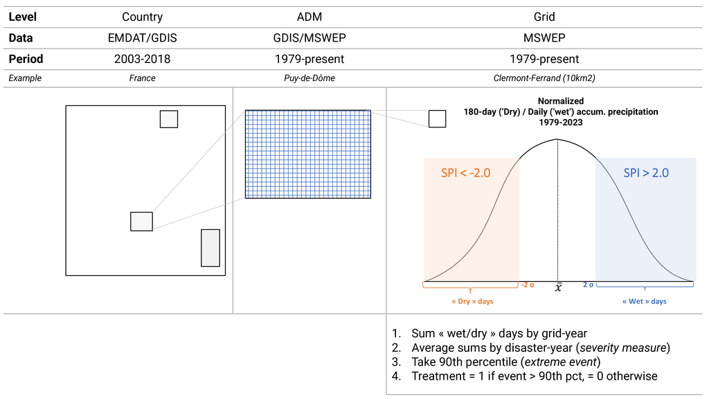

## Descriptive statistics

- Treat. X Country
- Treat. X Year
- Treat.Reg
- Outc.Vol

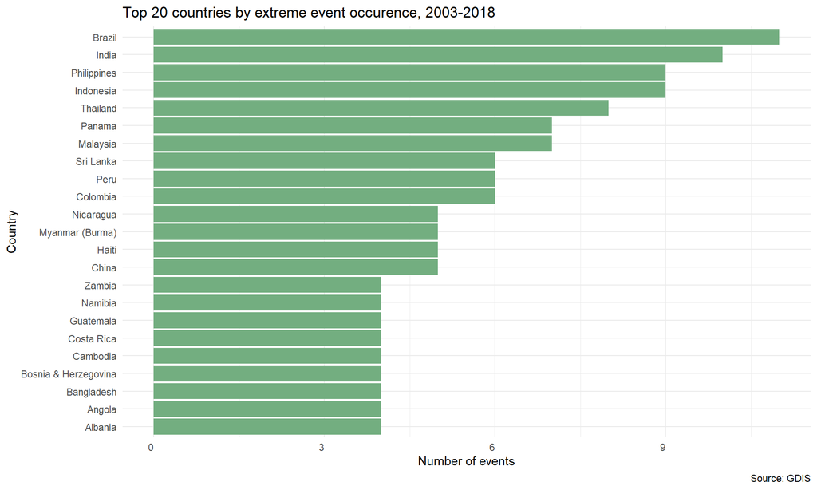

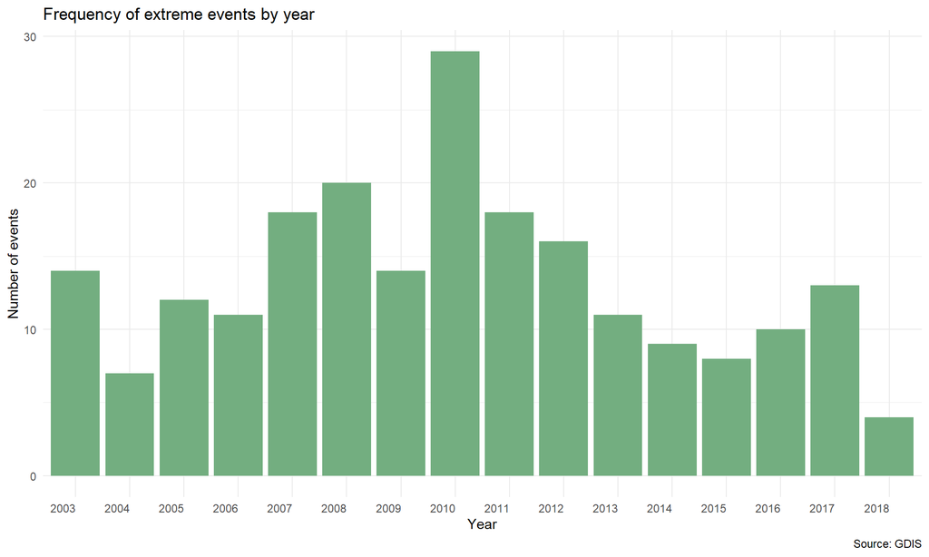

| **Characteristic** | **Extreme event** **Never treated** N = 86<sup>1</sup> | **Extreme event** **Treated** N = 72<sup>1</sup> | **Overall** N = 158<sup>1</sup> |  |
| --- | --- | --- | --- | --- |
| Region |  |  |  |  |
| Africa | 33 (38%) | 23 (32%) | 56 (35%) |  |
| Asia | 11 (13%) | 17 (24%) | 28 (18%) |  |
| Europe | 5 (5.8%) | 8 (11%) | 13 (8.2%) |  |
| LAC | 15 (17%) | 20 (28%) | 35 (22%) |  |
| Middle East | 9 (10%) | 1 (1.4%) | 10 (6.3%) |  |
| Oceania | 13 (15%) | 3 (4.2%) | 16 (10%) |  |

<sup>1</sup> n (%)

Country-level yearly ODA flows, by Region, 2003-2018

Source: OECD CRS

| Region | Min | Q1 | Median | Mean | Q3 | Max |
| --- | --- | --- | --- | --- | --- | --- |
| Africa | 0.00 | 113.88 | 390.20 | 698.65 | 977.45 | 7,396.70 |
| Asia | 3.45 | 142.08 | 402.21 | 982.35 | 1,192.38 | 7,627.13 |
| Europe | 0.00 | 26.12 | 230.01 | 473.10 | 502.39 | 5,585.25 |
| LAC | 0.00 | 15.04 | 55.87 | 207.54 | 263.05 | 3,454.66 |
| Middle East | 0.00 | 4.68 | 323.03 | 942.37 | 1,502.69 | 9,151.72 |
| Oceania | 0.00 | 17.57 | 41.22 | 86.33 | 102.88 | 822.74 |

- *Censored* outcome with a *skewed* distribution

## Baseline results

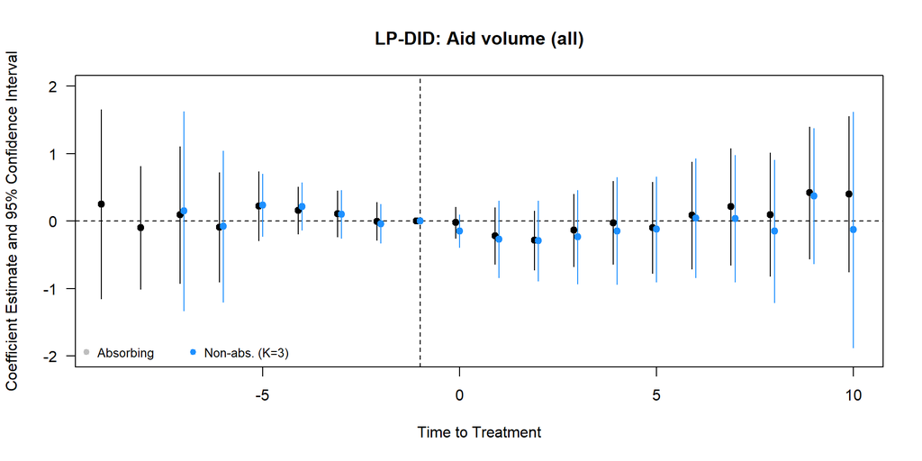

n.b. *not stabilized* (*revised* rainfall data coming soon)

## Robustness checks

### Treatment

✓ **Deviation cut-off** (non-linearity assumption): use the 95<sup>th</sup> or 99<sup>th</sup> percentiles

⨉ **Time-scale**: construct *year*-specific or *month*-specific distributions instead of day-specific

⨉ **Baseline climate** (climate belief assumption): choose 20-year or 30-year long historical norms

### Outcome

⨉ **Amount**: ODA disbursements

### Estimation

✓ **Lag length (stabilization period)**: no lag, 3-year, 5-year lags

✓ **Absorbing**: single (first-treated cohorts) and multiple (short/long-term) treatments (Deryugina 2017)

✓ **Estimators**: (*linear*) counterfactual/imputation estimators (Borusyak, Jaravel, and Spiess 2024; Liu, Wang, and Xu 2024), Generalized SCM (Xu 2017); (*nonlinear*) TWFE PPML, ETWFE (Wooldridge 2023)

⨉ **Multinomial models**: alternative estimators, e.g., fractional multinomial logit model (Negi and Jeffrey M. 2024), SCM for Proportions (multinomial link) (Bogatyrev and Stoetzer 2025)

## Heterogeneity

### Treatment

✓ **Exposure**: population, agricultural land, built-up area

⨉ **Climate extremes**: wet (flood) vs. dry (drought) events

### Outcome

✓ **Category**: humanitarian vs. development (Gov. & Civil society, Infrastructures)

⨉ **Channels of delivery**: NGO, Multi., Private

⨉ **Financial instruments**: grants vs. loans

⨉ **Donors**: bilateral vs. multilateral

### Recipient country

✓ **Gov. responsiveness**: State of Emergency and/or request for international assistance

⨉ **Domestic politics**: political regime and internal social conflict

⨉ **Resources**: income group, government’s fiscal and institutional capacity, Chinese aid

## Conclusion

- Study post-disaster aid allocation
  - Consider wet/dry climate extremes (floods/droughts)
  - Estimate dynamic effect on aid volume and composition
- Non-significant preliminary results on aid volume
- Potential explanations
  - identification strategy: rainfall extremes $\nRightarrow$ flooding ‘disasters’
  - variable construction meth.: alternative rainfall ‘extremes’ measures
  - level of analysis: miss sector-level effects and reallocation
- Revised precipitation data coming soon

# Annexes

## References

Aidt, Toke S., Facundo Albornoz, and Esther Hauk. 2021. “Foreign Influence and Domestic Policy.” *Journal of Economic Literature* 59 (2): 426–87. https://doi.org/10.1257/jel.20201481.

Arezki, Rabah, Youssouf Camara, Patrick Imam, and Kangni Kpodar. 2025. “Foreign Aid and (Big) Shocks: Evidence from Natural Disasters.” *IMF Working Papers* 2025 (006): 1. https://doi.org/10.5089/9798400299117.001.

Becerra, Oscar, Eduardo Cavallo, and Ilan Noy. 2014. “Foreign Aid in the Aftermath of Large Natural Disasters.” *Review of Development Economics* 18 (3): 445–60. https://doi.org/10.1111/rode.12095.

Bogatyrev, Konstantin, and Lukas Stoetzer. 2025. “Synthetic Control Methods for Proportions.” February 24, 2025. https://doi.org/10.31219/osf.io/brhd3_v2.

Borusyak, Kirill, Xavier Jaravel, and Jann Spiess. 2024. “Revisiting Event-Study Designs: Robust and Efficient Estimation.” *The Review of Economic Studies*, February, rdae007. https://doi.org/10.1093/restud/rdae007.

Carnegie, Allison, and Lindsay R. Dolan. 2021. “The Effects of Rejecting Aid on Recipients’ Reputations: Evidence from Natural Disaster Responses.” *The Review of International Organizations* 16 (3): 495–519. https://doi.org/10.1007/s11558-020-09393-y.

David, Antonio C. 2011. “How Do International Financial Flows to Developing Countries Respond to Natural Disasters?” *Global Economy Journal* 11 (4): 1850243. https://doi.org/10.2202/1524-5861.1799.

Dellmuth, Lisa M., Frida A.-M. Bender, Aiden R. Jönsson, Elisabeth L. Rosvold, and Nina von Uexkull. 2021. “Humanitarian Need Drives Multilateral Disaster Aid.” *Proceedings of the National Academy of Sciences* 118 (4): e2018293118. https://doi.org/10.1073/pnas.2018293118.

Deryugina, Tatyana. 2017. “The Fiscal Cost of Hurricanes: Disaster Aid Versus Social Insurance.” *American Economic Journal: Economic Policy* 9 (3): 168–98. https://www.jstor.org/stable/26598165.

Dietrich, Simone. 2013. “Bypass or Engage? Explaining Donor Delivery Tactics in Foreign Aid Allocation.” *International Studies Quarterly* 57 (4): 698–712. https://doi.org/10.1111/isqu.12041.

Dube, Arindrajit, Daniele Girardi, Òscar Jordà, and Alan M. Taylor. 2023. “A Local Projections Approach to Difference-in-Differences.” Working Paper. Working Paper Series. April 2023. https://doi.org/10.3386/w31184.

Felbermayr, Gabriel, and Jasmin Gröschl. 2014. “Naturally Negative: The Growth Effects of Natural Disasters.” *Journal of Development Economics*, Special Issue: Imbalances in Economic Development, 111 (November): 92–106. https://doi.org/10.1016/j.jdeveco.2014.07.004.

Flores, Alejandro Quiroz, and Alastair Smith. 2013. “Leader Survival and Natural Disasters.” *British Journal of Political Science* 43 (4): 821–43. https://doi.org/10.1017/S0007123412000609.

Grossman, Allison Namias. 2024. “No Relief: Why Do Aid-Dependent States Fail to Seek Humanitarian Aid?” February 26, 2024. https://www.peio.me/wp-content/uploads/PEIO16/submission_133.pdf.

IPCC, ed. 2023. “Weather and Climate Extreme Events in a Changing Climate.” In *Climate Change 2021 – The Physical Science Basis: Working Group I Contribution to the Sixth Assessment Report of the Intergovernmental Panel on Climate Change*, 1513–1766. Cambridge: Cambridge University Press. https://doi.org/10.1017/9781009157896.013.

Knack, Stephen. 2014. “Building or Bypassing Recipient Country Systems: Are Donors Defying the Paris Declaration?” *The Journal of Development Studies* 50 (6): 839–54. https://doi.org/10.1080/00220388.2014.895816.

Liu, Licheng, Ye Wang, and Yiqing Xu. 2024. “A Practical Guide to Counterfactual Estimators for Causal Inference with Time-Series Cross-Sectional Data.” *American Journal of Political Science* 68 (1): 160–76. https://doi.org/10.1111/ajps.12723.

Negi, Akanksha, and Wooldridge Jeffrey M. 2024. “Doubly Robust Estimation of Multivariate Fractional Outcome Means with Multivalued Treatments.” *Econometric Reviews* 43 (2–4): 175–96. https://doi.org/10.1080/07474938.2024.2310987.

Raschky, Paul A., and Manijeh Schwindt. 2012. “On the Channel and Type of Aid: The Case of International Disaster Assistance.” *European Journal of Political Economy* 28 (1): 119–31. https://doi.org/10.1016/j.ejpoleco.2011.07.001.

Waal, Alex de. 2017. *Mass Starvation: The History and Future of Famine*. Newark: Polity Press.

Wooldridge, Jeffrey M. 2023. “Simple Approaches to Nonlinear Difference-in-Differences with Panel Data.” *The Econometrics Journal* 26 (3): C31–66. https://doi.org/10.1093/ectj/utad016.

Xu, Yiqing. 2017. “Generalized Synthetic Control Method: Causal Inference with Interactive Fixed Effects Models.” *Political Analysis* 25 (1): 57–76. https://doi.org/f92fpt.

Yang, Dean. 2008. “Coping with Disaster: The Impact of Hurricanes on International Financial Flows, 1970-2002.” *The B.E. Journal of Economic Analysis & Policy* 8 (1). https://doi.org/10.2202/1935-1682.1903.